# Module 3: Classification

# Introduction

In machine learning and statistics, classification is the problem of identifying to which of a set of categories (sub-populations) a new observation belongs, on the basis of a training set of data containing observations (or instances) whose category membership is known. In other words, it is the process of assigning a new observation to a category based on historic observations and their categories.

In the terminology of machine learning, classification is considered an instance of **supervised learning** (i.e. learning where a training set of correctly identiﬁed observations is available). In contrast, if we don't have a dataset with labels of which categories the observations fall in, an unsupervised procedure for grouping data into categories based on some measure of inherent similarity or distance called clustering may be used.

# Learning Outcomes

By the end of this module, you will be able to:

- Conduct a binary classification
- Describe performance measures
- Recognize the process of multiclass classification
- Perform error analysis
- Describe multi-label classification

# Readings and Resources

We invite you to further supplement this notebook with the following recommended texts.

- Géron, A. (2019). Chapter 3: Classification in *Hands-On Machine Learning with Scikit-Learn, Keras, and TensorFlow* (2nd ed.). O’Reilly Media. https://www.oreilly.com/library/view/hands-on-machine-learning/9781492032632/
- Bishop, C.M. (2006). Chapter 3: Linear Models for Regression in *Pattern Recognition and Machine Learning* Springer. https://www.microsoft.com/en-us/research/uploads/prod/2006/01/Bishop-Pattern-Recognition-and-Machine-Learning-2006.pdf

# Supervised Machine Learning

Supervised Machine Learning is one of the most commonly used and successful types of machine learning. Supervised learning is used whenever:

- we want to predict a certain outcome from given feature variables, and
- we have examples of features and the target variable.

We build a machine learning model from the feature and target variables, which comprise our **training set**. Here feature variables may be thought of as inputs and the target variable can be thought of as the output. Our goal is to make accurate predictions for new, never-before-seen data based on the data the model has been trained on.

Supervised learning often requires human effort to build the training set, but afterward automates and often speeds up an otherwise laborious or infeasible task.

Supervised machine learning algorithms can be classification into two major types:

1. **Classification**: Classification is sometimes separated into **binary classification**, and **multiclass classification**. Binary classiﬁcation is a special case of distinguishing between exactly two classes, and multiclass, that of more than two classes. You can think of binary classiﬁcation as trying to answer a yes or no question. An example of a classiﬁcation problem would be handwritten digit recognition, in which the aim is to assign each input matrix of pixel values to one of ten discrete categories (0-9). Another way to think of classiﬁcation is as a discrete (as opposed to continuous) form of supervised learning where one has a limited number of categories and for each of the n samples provided, one is to try to label them with the correct category or class.
2. **Regression**: For regression tasks, the goal is to predict a number from a continuous scale (a ﬂoating-point number in programming terms). Predicting house prices from information like number of bedrooms, area of neighbourhood, number of schools, zip code, facilities available, etc. can be an example of a regression problem. Predicting a person’s annual income from their education, their age, and where they live is another example of a regression task. When predicting income, the predicted value is an amount, and can be any number in a range. Another example of a regression task is predicting the yield of a farm given attributes such as previous yields, weather, irrigation facilities, use of pesticides and number of employees working on the farm. The yield again can be an arbitrary (positive) number.

An easy way to distinguish between classification and regression tasks is to ask whether there is some kind of continuity in the output. If there is continuity between possible outcomes, then the problem is a regression problem.

In this module, we will study various classiﬁcation methods in detail and cover how to perform error analysis and interpret performance measures.

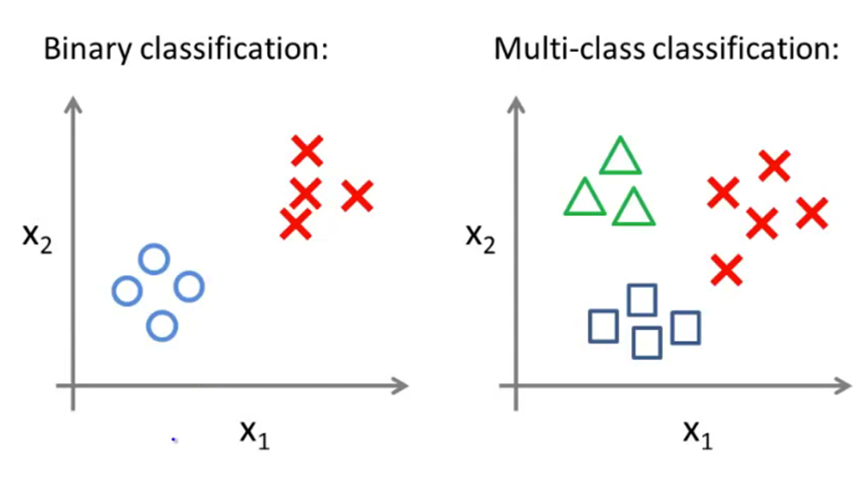

Image: Schematic representation of Binary and Multi-class classification

There are variety of different modelling approaches for classification. Some examples include:

- Logistic Regression (yes, this is Classification as the output is a class; don’t be fooled by the name)
- Tree-based models
- K-Nearest Neighbours
- Neural Net Classifiers

A comprehensive list of models available for supervised machine learning for scikit learn is here:

https://scikit-learn.org/stable/supervised_learning.html#supervised-learning (https://scikit-learn.org/stable/supervised_learning.html#supervised-learning)

You may use any of these to explore a dataset, and in the exercise just below.

## Exercise

In order to understand binary classiﬁcation, we will look at a dataset to predict whether a patient has diabetes or not. We will use a dataset from a Kaggle contest. It has been provided as a separate .csv file with this module (source: https://www.kaggle.com/uciml/pima-indians-diabetes-database).

The dataset consista of several medical predictor (independent) variables and one target (dependent) variable, “outcome”.

Independent variables include the number of pregnancies the patient has had, their BMI, insulin level, age, and so on.

The notebook provided with this module entitled `pima-indian-diabetes-binary-classification.ipynb` runs through a few models and classiﬁes each record containing patient data and classiﬁes it to 1 or 0; 1 being the indicator for patient having diabetes and 0 for no diabetes.

Please note that the exercise is only to show the notion of classiﬁcation and is only at an exploratory level.

Open the notebook provided, and follow along through the process as you go through the following content. The sections below will explain what the examples in the exercise are doing.

Once you are satisfied with your solution, share it with your peers along with your rationale in the LEARN Discussion forum. There are likely to be many solutions, each with their own strengths and weaknesses.

## Training a binary classifier

The exercise above shows the entire program on how to explore a dataset, and how to train the classiﬁer. It included sample code for a few classiﬁers. As always, keep the official documentation handy for guidance. In this case, the scikit learn documentation provides detailed information for you when you need it. https://scikit-learn.org/stable/supervised_learning.html#supervised-learning

### Evaluation of the model

A good way to evaluate a model is to use cross-validation.

Cross-validation is a resampling procedure used to evaluate machine learning models when the data sample is limited and we need to use all of it for training (i.e. we can't afford to put some of it aside strictly for testing). The idea is that we will train the model several times, each time putting aside a different subset for testing, and see if the model still performs well each time. If not, we can't have any confidence that we have enough data for the model to be useful.

The procedure has a single parameter called 'k' that refers to the number of groups that a given data sample is to be split into. As such, the procedure is often called **k-fold cross-validation**. For example, in a 10-fold cross-validation, we would:

- reserve the first 10% of the data for testing and train on the remaining 90%; train & test
- reserve the next 10% of the data for testing and train on the remaining 90%; train & test
- continue for 8 additional rounds until all of the data has been used once for testing

Note that this assumes that the data is in no particular order (for example, that it is not timeseries data). If so, the data should be shuffled first so that the reserved testing sets are all representative.

**NOTE:** If the distribution of the target variable is skewed (i.e., when some classes are much more frequent than others), **accuracy is not generally a preferred performance measure for classifiers**. We will review other ways of evaluating a model.

See the following thread on Stack exchange for some insight:

https://stats.stackexchange.com/questions/312780/why-is-accuracy-not-the-best-measure-for-assessing-classification-models

### Confusion Matrix

A confusion matrix is a summary of prediction results on a classification problem. The number of correct and incorrect predictions are summarized with count values and broken down by each class. It gives you insight not only into the errors being made by your classifier but more importantly the types of errors that are being made. It is this breakdown that overcomes the limitation of using classification accuracy alone.

Below is the process for calculating a confusion Matrix.

1. You need a test dataset or a validation dataset with expected outcome values.
2. Make a prediction for each row in your test dataset.
3. From the expected outcomes and predictions count:
   - The number of correct predictions for each class.
   - The number of incorrect predictions for each class, organized by the class that was predicted.

These numbers are then organized into a table, or a matrix as follows:

- *Predicted values down the side*: Each row of the matrix corresponds to a class predicted by the model for test observations.
- *Actual across the top*: Each column of the matrix corresponds to the actual class label on the test observation.

(or vice-versa; be sure to check which way the library you're using presents the results!)

The counts of correct and incorrect classification are then filled into the table.

The total number of correct predictions show up along the diagonal. The off-diagonal entries show how often that particular misclassification occurs (for example, mistaking an 8 for a 6 in digit recognition or diabetes for not in this example):

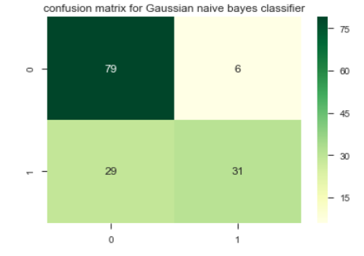

The image shows confusion matrix for the Gaussian naive Bayes classifier in the diabetes classification problem that was discussed earlier. Types of errors may be deduced from the confusion matrix.

The confusion matrix gives you a lot of information, but sometimes you may prefer a more concise metric. An interesting one to look at is the **accuracy of the positive predictions**.

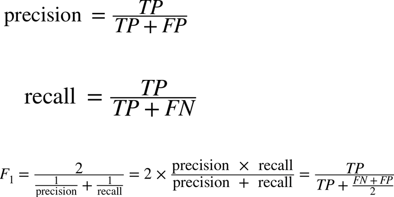

- **TP** is the number of true positives, and **FP** is the number of false positives. A trivial way to have perfect **Precision** is to make one single positive prediction and ensure it is correct (precision = 1/1 = 100%). This would not be very useful since the classifier would ignore all but one positive instance. So precision is typically used along with another metric named Recall, also called Sensitivity or True Positive Rate (TPR): this is the ratio of positive instances that are correctly detected by the classifier.
- **FN** is the number of false negatives.

There are several other measures that are commonly used including **Sensitivity**, **Specificity** and **Accuracy**. They are all based on counts or rates of **true positives (TP)**, **true negatives (TN)**, **false negatives (FN)**, and **false positives (FP)**.

To understand the relations between *TP, FN, Accuracy* and *Precision*, let us look at an example below.

Let's explore with an example: if a disease is proven present in a patient, and the given diagnostic test also indicates the presence of disease, the result of the diagnostic test is considered true positive. The test was positive, as was true.

Similarly, if a disease is proven absent in a patient, and the diagnostic test suggests the disease is absent as well, the test result is true negative (TN).

Both a true positive and true negative suggest a consistent result between the diagnostic test and the proven condition (also called *standard of truth*). However, no medical test is perfect. If the diagnostic test indicates the presence of disease in a patient who actually has no such disease, the test result is false positive (FP).

Similarly, if the result of the diagnosis test suggests that the disease is absent for a patient who actually has the disease, the test result is false negative (FN). Both a false positive and false negative indicate that the test results are opposite to the actual condition.

#### Sensitivity, specificity and accuracy are described in terms of TP, TN, FN and FP

- Sensitivity = TP/(TP + FN) = (Number of true positive assessment)/(Number of all positive assessment)
- Specificity = TN/(TN + FP) = (Number of true negative assessment)/(Number of all negative assessment)
- Accuracy = (TN + TP)/(TN+TP+FN+FP) = (Number of correct assessments)/Number of all assessments)

As suggested by the equations above:

- **Sensitivity** is the proportion of true positives that are correctly identified. In our example, it shows how good the test is at detecting the disease.
- **Specificity** is the proportion of the true negatives correctly identified. It would suggest how good the test is at identifying normal (negative) conditions in our example.
- **Accuracy** is the proportion of true results, either true positive or true negative, in a population. It can be considered to be measuring the degree of correctness or *veracity* of a diagnostic test for a condition.

The numerical value of **specificity** represents the probability that a test diagnoses a particular disease without giving false-positive results. For example, if the specificity of a test is 99%, it means: when we conduct a diagnostic test on a patient without this disease, there is a 99% chance that this patient will be identified as negative.

**NOTE:** A test can be very specific without being sensitive, or it can be very sensitive without being specific. Both factors are equally important. A good test is one that has both high sensitivity and specificity. A good example of a test with high sensitivity and specificity is a pregnancy test. A positive result of pregnancy test almost certainly identifies the subject who took the test as being pregnant. A negative result almost certainly rules out the possibility of being pregnant.

In addition, **accuracy** can be determined from sensitivity and specificity, where *prevalence* is known. *Prevalence* is the probability of disease in the population at a given time:

- Accuracy = (sensitivity) (prevalence) + (specificity) (1 - prevalence)

The numerical value of accuracy represents the proportion of true positive results (both true positive and true negative) in the selected population. An accuracy of 99% means that the test is accurate 99% of the time, regardless if the test is positive or negative.

**NOTE:** It is worth mentioning that the way accuracy is defined means that even if both sensitivity and specificity are high, say 99%, it does not mean that the accuracy of the test is equally high as well. In addition to sensitivity and specificity, the accuracy is also affected by how common the disease is in the selected population. A diagnosis for rare conditions in the population of interest may result in high sensitivity and specificity, but low accuracy. All of these measures are important and contribute to understanding how good a model is.

### Accuracy, Precision, Recall and F1 Score

Let's review accuracy, precision and recall. Then we will introduce another measure, F1 Score.

- **Accuracy** s the most intuitive performance measure and it is simply a ratio of correctly predicted observation to the total observations. One may think that, if we have high accuracy then our model is best. Accuracy is a great measure but only when you have symmetric datasets where values of false positive and false negatives are almost the same. Therefore, you often have to look at other parameters to evaluate the performance of your model. Accuracy is calculated as follows:

  $$Accuracy = (TP+TN)/(TP+FP+FN+TN)$$
- **Precision** is the ratio of correctly predicted positive observations to the total predicted positive observations. Precision is calculated as follows: NOTE: Take note of the difference in the denominator when compared to the accuracy calculation.

$$Precision = TP/(TP+FP)$$

- **Recall (Sensitivity)** is the ratio of correctly predicted positive observations to the all observations in actual class - yes.

$$Recall = TP/(TP+FN)$$

- **F1 Score** is the weighted average of Precision and Recall. Therefore, this score takes both false positives and false negatives into account. Intuitively it is not as easy to understand as accuracy, but F1 is usually more useful than accuracy, especially if you have an uneven class distribution. Accuracy works best if false positives and false negatives have similar cost. This often isn't the case with medical testing: a false positive may result in additional testing which ultimately rules out the disease whereas a false negative could cost a patient their life.

If the cost of false positives and false negatives are very different, it’s better to look at both Precision and Recall or to combine them as the F1 Score. It is calculated as follows:

$$F1 Score = 2*(Recall * Precision) / (Recall + Precision)$$

### Uncertainity

The confusion matrix and the classiﬁcation report provide a very detailed analysis of a particular set of predictions. However, there is more information that may be useful that is not available from these alone. Most classiﬁers provide a decision function or a predict_proba() method to assess degrees of certainty about predictions. Making predictions can be seen as thresholding the output of a decision function or *predict_proba* at a certain ﬁxed point. In binary classiﬁcation, we typically use Class "0" (usually "false") for the decision function and 0.5 for *predict_proba*. This means that classifier predicts the label "1" when the probability is greater than 0.5 and label "0" when the probability is less than 0.5. We are, by default, using 0.5 as the threshold to differentiate between the two labels.

Increasing the threshold means that the model needs to be more conﬁdent than 50% to choose Class "1" as output. If our classes are "Not Under Attack" and "Under Attack" we can say we want to be more than 50% sure we're "Under Attack" before calling it as such.

While working with probabilities may be more intuitive than working with arbitrary thresholds, unfortunately not all models provide realistic models of uncertainty.

### Precision-Recall Tradeoff

As we just discussed, changing the threshold that is used to make a classiﬁcation decision in a model is a way to adjust the trade-oﬀ of precision and recall for a given classiﬁer. Maybe you want to miss no more than 10% of positive cases, meaning a desired recall of 90%. This decision depends on the application, and it should be driven by business or scientific goals. Once a particular goal is set — say, a particular recall or precision value for a class — a threshold can be set appropriately. It is always possible to set a threshold to fulﬁll a particular target, like 90% recall. The hard part is to develop a model that still has reasonable precision with this threshold—if you classify everything as positive, you will have 100% recall, but your model will be useless. Setting a requirement on a classiﬁer like 90% recall is often called "fixing the operating point". Fixing an operating point is often helpful in business settings to make performance guarantees to customers or other groups inside your organization.

Often, when developing a new model, it is not entirely clear what the operating point will be. For this reason, and to understand a modeling problem better, it is instructive to look at all possible thresholds, or all possible trade-oﬀs of precision and recall at once. This is possible using a tool called the precision-recall curve, or PR curve. You can ﬁnd the function to compute the precision-recall curve in the sklearn.metrics module. It needs the ground truth (i.e. correct, observed) labeling and predicted uncertainties, created via either decision_function or *predict_proba*.

### The ROC Curve

The **receiver operating characteristic (ROC)** curve is another common tool used with binary classifiers. It is very similar to the precision/recall curve, but instead of plotting precision versus recall, the ROC curve plots the true positive rate (another name for recall) against the false positive rate. The FPR is the ratio of negative instances that are incorrectly classified as positive. It is equal to one minus the true negative rate (TNR), which is the ratio of negative instances that are correctly classified as negative. The TNR is also called **specificity**. Hence the ROC curve plots sensitivity (recall) versus 1 – specificity.

To plot the ROC curve, TPR and FPR need to be computed for various threshold values, using the roc_curve() function. This function is available in the scikit-learn library.

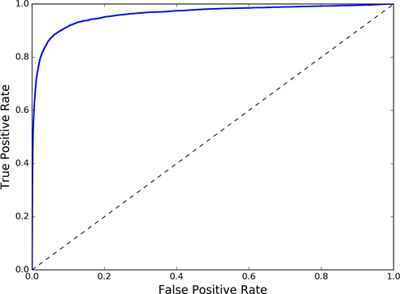

Source: Géron, A. (2019). Chapter 3: Classification in *Hands-On Machine Learning with Scikit-Learn, Keras, and TensorFlow* (2nd ed.). O’Reilly Media. https://www.oreilly.com/library/view/hands-on-machine-learning/9781492032632/

Once again there is a tradeoff: the higher the recall (TPR), the more false positives (FPR) the classifier produces. The dotted line represents the ROC curve of a purely random classifier; a good classifier stays as far away from that line as possible (toward the top-left corner).

One way to compare classifiers is to measure the **area under the curve (AUC)**. A perfect classifier will have a ROC AUC equal to 1, whereas a purely random classifier will have a ROC AUC equal to 0.5. Scikit-Learn provides a function to compute the ROC AUC (roc_auc_score() function).

#### PR Curve versus ROC curve

AUC - ROC curve is a performance measurement for classification problem at various thresholds settings. ROC is a probability curve and AUC represents degree or measure of separability. It tells how much model is capable of distinguishing between classes. Higher the AUC, better the model is at predicting 0s as 0s and 1s as 1s. By analogy, Higher the AUC, better the model is at distinguishing between patients with disease and no disease

### Comparing ROC curves

To compare different classifiers, we plot the ROC curves for each classifier. The classifier whose ROC curve is closer to top-left corner is better. This is also reflected in a better ROC AUC score (closest to 1).

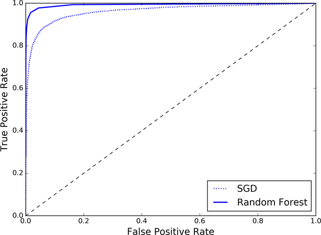

Source: Géron, A. (2019). Chapter 3: Classification in *Hands-On Machine Learning with Scikit-Learn, Keras, and TensorFlow* (2nd ed.). O’Reilly Media. https://www.oreilly.com/library/view/hands-on-machine-learning/9781492032632/

`RandomForestClassfier`’s ROC curve looks much better than the `SGDClassifier`’s: it comes much closer to the top-left corner. As a result, its ROC AUC score is also signficantly better. Therefore, we would choose the `RandomForestClassifier` in this case over the `SGDClassifier`.

## Multiclass classification

Multiclass classiﬁers can distinguish between two or more classes.

One way to create a system that can classify n-classes is to train n-binary classiﬁers, one for each class. Then when you want to classify a new instance, you get the decision score from each classiﬁer and select the class with the highest score. (one-versus-all (OvA) strategy) Another way, is to train a binary classiﬁer for every pair of classes. This is called the one-versus-one (OvO) strategy. If there are N classes, you need to train N × (N – 1) / 2 classiﬁers!

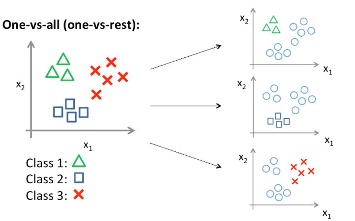

### One-vs-one classifier

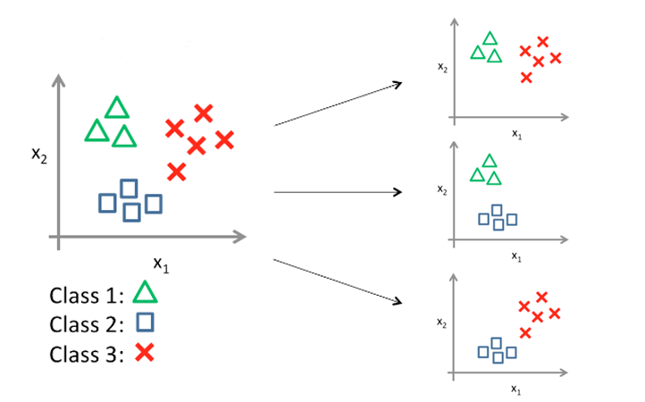

Open the notebook provided in this module entitled `plot_digits_classification.ipynb`. It is a classiﬁcation problem to identify digits between 0-9. The dataset has several instances of data points (i.e., images) and labels (0-9). The model is trained using the dataset provided and predicts class labels for new images. In the example, we will be using SVM as the classiﬁer. Try out using other classiﬁers and see how they perform. Try the various evaluation metrics.

## Multi-Output Classification

In some cases, you may want your classiﬁer to output multiple classes for each instance. For example, consider a face-recognition classiﬁer: what should it do if it recognizes several people on the same picture? Of course, it should attach one label per person it recognizes. Say the classiﬁer has been trained to recognize three faces, Alice, Bob, and Charlie; then when it is shown a picture of Alice and Charlie, it should output [1, 0, 1] (meaning “Alice yes, Bob no, Charlie yes”). Such a classiﬁcation system that outputs multiple binary labels is called a multilabel classiﬁcation system.

**End of Module**

This notebook makes up one part of this module. Now that you have completed this part, please proceed to the next notebook in this module.

If you have any questions, please reach out to your peers using the discussion boards. If you and your peers are unable to come to a suitable conclusion, do not hesitate to reach out to your instructor on the designated discussion board.

# References

Davis, J. & Goadrich, M. (2006). The Relationship Between Precision-Recall and ROC Curves. University of Wisconsin at Madison. *Proceedings of the 23rd International Conference on Machine Learning*. Retrieved from https://www.biostat.wisc.edu/~page/rocpr.pdf

OC vs PR curves discussion on Stackexchange. Retrieved from https://stats.stackexchange.com/questions/201750/good-classifier-destroyed-my-precision-recall-curve-what-happened

ROC vs PR curves discussion on Stackexchange. Retrieved from: https://stats.stackexchange.com/questions/7207/roc-vs-precision-and-recall-curves

Scikit learn documentation. Retrieved from https://scikit-learn.org/stable/

Statistical Classification (n.d.) https://en.wikipedia.org/wiki/Statistical_classiﬁcation (https://en.wikipedia.org/wiki/Statistical_classiﬁcation)

Zhu, W., Zeng, N., & Wang, N., (2010). *Sensitivity, Specificity, Accuracy, Associated Confidence Interval and ROC, Analysis with Practical SAS® Implementations*. K&L consulting services, Inc. and Octagon Research Solutions. Retrieved from https://www.lexjansen.com/nesug/nesug10/hl/hl07.pdf.